# メトロポリス・ヘイスティングス法

```r
# delta_e = 0.00001
qsd <- sqrt(0.00001)   #提案分布のＳＤ
Nsi <- 10^5+100    #サンプルサイズ
Bin <- 10^2        #バーンイン期間
rwmh(qme, qsd, Nsi, Bin)
```

```
## [1] "Run Time"
## 採択率[1] 0.994036
## モンテカルロ積分
## Mean[1] 1.356
## Var[1] 0.352
## SD[1] 0.593
```

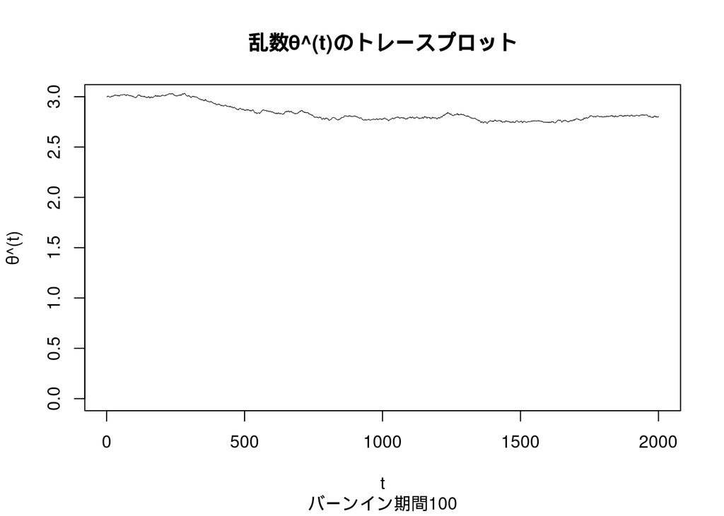

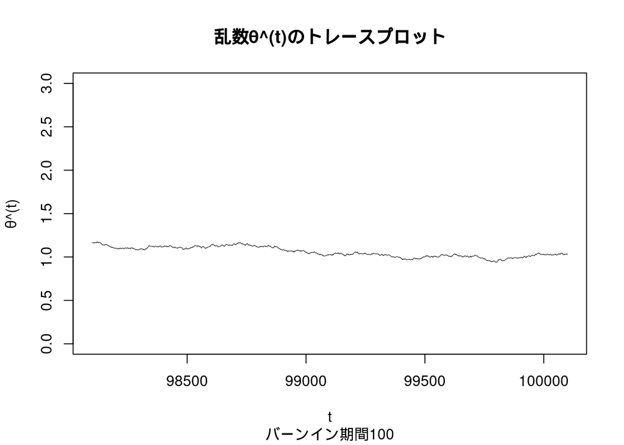

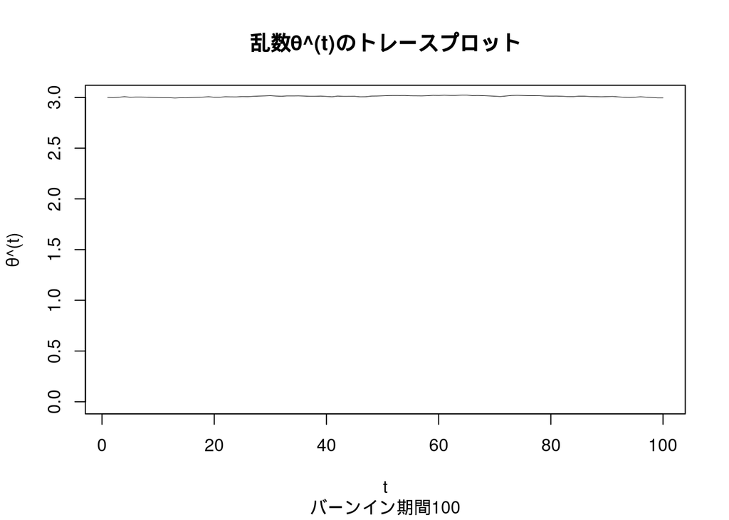

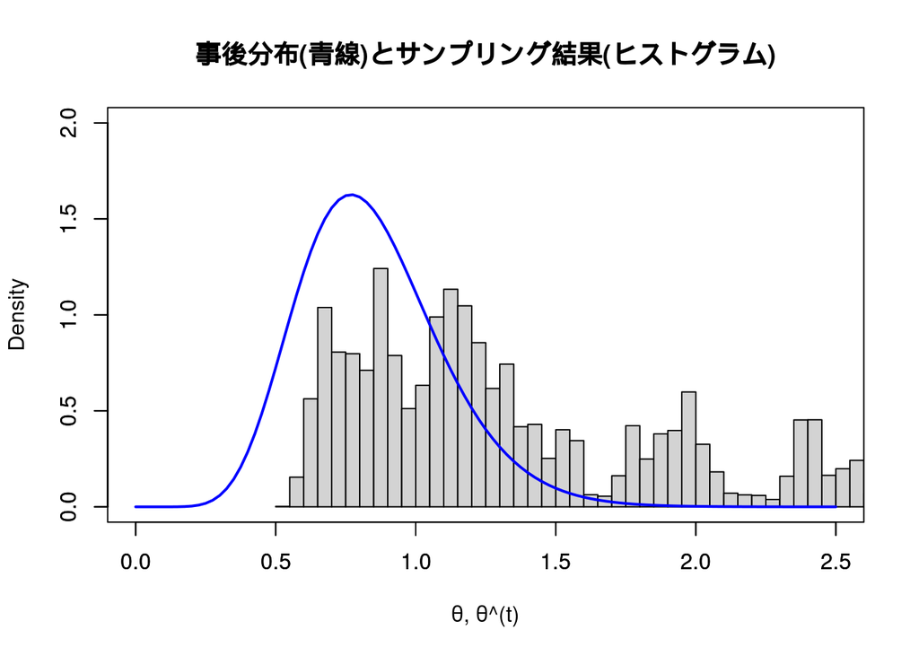

先の例題ではポアソン分布のパラメータ1つだけの推定でしたが、回帰モデルを推定する際、回帰モデルには複数推定するパラメータがあります。なのでRWMHはその分だけノイズの分散$\delta_{e1}, \delta_{e2}, ..., \delta_{ek}$を設定し、別々に乱数をサンプリングしなければなりません。こうなるとハイパーパラメータの設定はさらに難しくなります。

$$\begin{eqnarray}
回帰モデル \\
y &=& \beta_0 + \beta_1 X_1+ \beta_2 X_2 + \cdots + \beta_k X_k + u, \ u \sim N(0, \sigma^2) \\
\iff y|_{{\bf X}, \beta_1, \beta_2, \cdots, \beta_k, \sigma} &\sim& N(\beta_0 + \beta_1 X_1+ \beta_2 X_2 + \cdots + \beta_k X_k, \sigma^2) \\
乱数候補のランダムウォーク \\
\left(
\begin{array}{c}
a_{\beta_0}^{(t)} \\
a_{\beta_1}^{(t)} \\
\vdots \\
a_{\beta_k}^{(t)} \\
a_{\sigma}^{(t)} \\
\end{array}
\right) &=&
\left(
\begin{array}{c}
\beta_0^{(t-1)} \\
\beta_1^{(t-1)} \\
\vdots \\
\beta_k^{(t-1)} \\
\sigma^{(t-1)} \\
\end{array}
\right) +
\left(
\begin{array}{c}
e_{\beta_0} \\
e_{\beta_1} \\
\vdots \\
e_{\beta_k} \\
e_{\sigma} \\
\end{array}
\right) \\
\left(
\begin{array}{c}
e_{\beta_0} \\
e_{\beta_1} \\
\vdots \\
e_{\beta_k} \\
e_{\sigma} \\
\end{array}
\right) &\sim& N \left(
\begin{array}{c}
0, \delta_{e\beta_0}^2 \\
0, \delta_{e\beta_1}^2 \\
\vdots \\
0, \delta_{e\beta_k}^2 \\
0, \delta_{e\sigma}^2 \\
\end{array}
\right)
\end{eqnarray}$$

参考:  
豊田秀樹 編著(2015)「基礎からのベイズ統計学・ハミルトニアンモンテカルロ法による実践的入門」朝倉書店